# Gráfico de Control

El gráfico de control es una herramienta útil para determinar si un proceso está en estado de control o no, y también se utiliza ampliamente como un medio de análisis del proceso.

- El propósito y los principios de las gráficas de control, así como la variabilidad por causas comunes y por causas especiales.
- El significado del estado de control estadístico.
- Tipos de gráficos de control.
- Elaboración de gráficas de control $ \bar{X} - R $, $ p $, y $ np $, y cálculo de sus líneas de controle.
- Interpretación de gráficas de control y cómo determinar el estado de control estadístico.

[Audio_1](https://drive.google.com/file/d/1sNNFzaUGXwfksGe4lhNxQ9R6_a_3ltMQ/view?usp=drive_link)

```python
import os
import sys

try:
  os.chdir('../Python/QCKentei3')
except:
  pass

sys.path.append(os.path.abspath(os.path.join("..","Common")))
path = os.getcwd()

path
```

```
'/Users/takanohiroshi/Library/CloudStorage/OneDrive-個人用/Documenten/Python/QCKentei3'
```

```python
import numpy as np
import matplotlib.pyplot as plt
import pandas as pd
import random
from scipy.stats import norm

from chart import QCChart, QCChart2
from IPython.display import Image, display
import base64

import gspread
from google.oauth2.service_account import Credentials
```

## 05-01 Definición de gráfico de control

管理図とは

### 1. Definición de gráfico de control

管理図とは

El gráfico de control fue ideado por W. A. Shewhart como una herramienta para gestionar o analizar procesos. Su propósito es detectar anomalías en el proceso y determinar estadísticamente si la variabilidad del proceso se debe únicamente a causas aleatorias (es decir, el proceso está en estado de control estadísticos) o no.

- Variabilidad debida a **causas aleatorias**: 偶然原因によるばらつき Variabilidad que ocurre incluso cuando la fabricación se basa en estándares técnicamente bien considerados para materias primas, métodos de trabajo, maquinaria y equipos, variabilidad que no es necesario eliminar técnica o económicamente; variabilidad causada por factores imposibles de controlar.
- Variabilidad debida a **causas asignables** /Variabilidad debida a **causas especiales**: 異常原因によるバラツキ Variabilidad que surge debido a que el trabajo no se realiza según los estándares o porque los estándares no son adecuados; variabilidad que técnicamente **no se puede ignorar**.

En el gráfico de control, se establecen los **límites de control**（管理限界） como criterio de decisión para determinar si el proceso está en estado de control. En cualquier gráfico de control, los límites de control se calcula mediante lo siguiente.

- (Media)± 3 × (desviación estándar)

Este tipo de gráfico de control se denomina gráfico de control de **3 sigma**（３σ法）. Se considera que el proceso está en **estado de control**（管理状態） cuando todos los puntos se encuentran **dentro de los límites**（管理限界内） de control y **no hay patrones inusuales**（癖のない） en la disposición de los puntos.

### 2. Tipo de gráfico de control

管理図の種類

- Gráfico de control para valores medidos
  - Gráfico de control **$ \bar{X} - R $** (gráfico de control de la media y el rengo por grupos)
- Gráfico de control para valores contados
  - Gráfico de control **p** (gráfico de control de la tasa de defectuosos)
  - Gráfico de control **np** (gráfico de control del número de defectuosos)

#### (1) Gráfico de control para **análisis**

解析用の管理図

- Se utiliza para investigar si el proceso actual está bajo control estadístico.
- Utilizando los datos obtenidos durante un periodo determinado, se grafican los datos de cada grupo y **se calculan los límites de control**. A partir de cada punto y los límites de control, se determina si el proceso está bajo control estadístico.
- En la etapa de recolección de datos, **no se proporcional** límites de control

### (2) Gráfico de control para **gestión**

管理用の管理図

- Se utiliza para determinar si el estado de control se mantiene cuando se ha juzgado que el proceso está bajo control
- **Se extienden los límites de control ya calculados** y se grafican sucesivamente los datos de cada nuevo grupo para determinar si el proceso permanece bajo control estadístico.
- En la etapa de recolección de datos, **se proporcionan** límites de control.

[Audio_2](https://drive.google.com/file/d/1Hmii2cVXU1WEt9BHsdkOG2i2idla6a5c/view?usp=drive_link)

## 05-02 Cómo hacer un gráfico de control

管理図のつくり方

### 1. Cómo hacer un gráfico de control $ \bar{X} - R $

(gráfico de control de la media y el rango por grupos)

El **gráfico de control $ \bar{X} - R $** está compuesto por dos gráficos: el **gráfico $ R $**, que gestiona y analiza la variabilidad dentro de los grupos para **valores medidos** como longitud, peso , rendimiento, etc., y el **gráfico $ \bar{X} $**, que gestiona y analiza la variabilidad de la media del proceso.

Paso 1: Recopilar los datos.

- Es preferible utilizar datos relativamente recientes. El número total de datos es resultado del tamaño del grupo (n) multiplicado por el número de grupos (k). Además, se considera apropiado que el número de grupos (k) esté entre **20 y 30**.

Paso 2: Dividir en grupos.

- Los grupos deben formarse de manera que sean lo más **homogéneos** posible, por ejemplo, agrupando datos del mismo día de fabricación o del mismo lote, evitando que datos heterogéneos se incluyan en el mismo grupo. El tamaño del grupo generalmente debe ser de **2 a 5**.
- **Tamaño del grupo**: el número de datos recolectados en un solo grupo (por ejemplo, en un día)
- **Número de grupos**: el número de grupos (por ejemplo, días) en el periodo en que se recolectaron los datos.

Paso 3: Registrar los datos divididos en una hoja de datos.

Paso 4: Calcular el valor medio $ \bar{X} $ y rango $ R $ para cada grupo.

$ \bar{X} = \frac{1}{n} \sum X $

$ R = X_{max} - X_{min} $

Paso 5: Calcular el valor medio total $ \bar{\bar{X}} $ y el valor medio del rango $ \bar{R} $.

$ \bar{\bar{X}} = \frac{1}{k} \sum {\bar{X}} $

$ \bar{R} = \frac{1}{k} \sum R $

Paso 6: Determinar las líneas de control.

#### Línea de control del gráfico X

- Línea central $ CL = \bar{X} $
- Línea superior de control (UCL) $ UCL = \bar{X} + A_2 \bar{R} $
- Línea inferior de control (LCL) $ LCL = \bar{X} - A_2 \bar{R} $

#### Línea de control del gráfico R

- Línea central $ CL = \bar{R} $
- Línea superior de control (UCL) $ UCL = D_4 \bar{R} $
- Línea inferior de control (LCL) $ LCL = D_3 \bar{R} $

Ten en cuenta que cada coeficiente del gráfico de control $ \bar{X} - R $ se determina según el **tamaño del grupo**.

Paso 7: Crear el diagrama de control.

Paso 8: Graficar los datos.

Paso 9: Registrar los detalles necesarios.

[Audio_3](https://drive.google.com/file/d/1ZdkYbNzhWMcK2Cx2Tsznumlkg6pkPQ5r/view?usp=drive_link)

```python
import calculate_control_limits_factors

df = pd.DataFrame()

for i in np.arange(2,6):
  sample_size = i

  A2, D3, D4, B3, B4 = calculate_control_limits_factors.f(sample_size)

  A = [A2,D3,D4]
  df[i] = A

df = df.T
df.columns = ['A2','D3','D4']

print("Tabla de coeficientes para gráficos de control Xbar-R:")

df
```

```
Tabla de coeficientes para gráficos de control Xbar-R:
```

|  | A2 | D3 | D4 |
| --- | --- | --- | --- |
| 2 | 1.880 | 0.0 | 3.267 |
| 3 | 1.023 | 0.0 | 2.574 |
| 4 | 0.729 | 0.0 | 2.282 |
| 5 | 0.577 | 0.0 | 2.115 |

## 5.1

最近、不適合品の発生率が多くなっている。工程の状況を調査するため一日４個のサンプルをランダムに採取し３０日間にわたって製品特性値のデータを収集した（表５．２）。これらのデータを用いて$ \bar{X} - R $ 管理図を作成せよ。

Recientemente, la tasa de productos defectuosos ha aumentado. Para investigar la situación del proceso, se tomaron al azar 4 muestras por día y se recopilaron datos sobre la características del producto durante 30 días (Tabla 5.2). Utilice estos datos para crear gráfico $ \bar{X} - R $.

```python
SERVICE_ACCOUNT_FILE = "my-project-vscode-452201-249bdb033f8c.json"  # JSONファイルのパス
SCOPES = ["https://www.googleapis.com/auth/spreadsheets"]

credentials = Credentials.from_service_account_file(SERVICE_ACCOUNT_FILE, scopes=SCOPES)
client = gspread.authorize(credentials)

# スプレッドシートを開く（URLまたはスプレッドシートIDを使用）
SPREADSHEET_ID = "1kqN4PUhamo1jwqudnaHuaUSWvNX4tIbVTY5YU4g9r3A"
sheet = client.open_by_key(SPREADSHEET_ID).worksheet("Sheet16") # 最初のシートを取得

# データを取得
list_of_lists = sheet.get_all_records()
df = pd.DataFrame(list_of_lists)

df = df.set_index('Número_de_Grupo')
df = df.astype(float)

print('Tabla 5.2')
print(df)
```

```
Tabla 5.2
                    x1     x2     x3     x4
Número_de_Grupo
1                533.0  480.0  524.0  520.0
2                549.0  480.0  538.0  495.0
3                560.0  489.0  489.0  487.0
4                490.0  425.0  476.0  518.0
5                548.0  521.0  480.0  538.0
6                488.0  525.0  450.0  456.0
7                442.0  420.0  409.0  500.0
8                508.0  531.0  476.0  505.0
9                500.0  530.0  421.0  507.0
10               436.0  456.0  506.0  520.0
11               456.0  471.0  410.0  423.0
12               449.0  411.0  454.0  495.0
```

[output cut: 18 more lines]

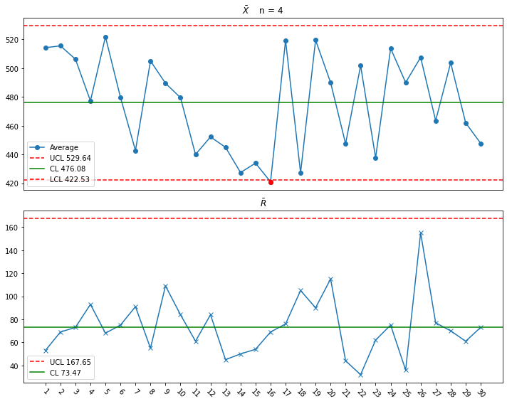

```python
from chart import QCChart2
import io

# メモリ上にCSV出力（バイト型 or テキスト型）
csv_buffer = io.StringIO()
df.to_csv(csv_buffer, index=True)
# バッファの先頭に戻す
csv_buffer.seek(0)

# アップロードAPI等に渡す場合に使える
csv_data = csv_buffer.getvalue()

chart = QCChart2(csv_buffer,4)
fig = chart.plot_xbar_chart()

plt.show()
```

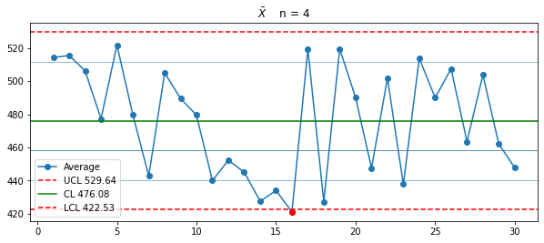

```python
chart = QCChart(df)
fig = chart.plot_xbar_chart()

plt.show()
```

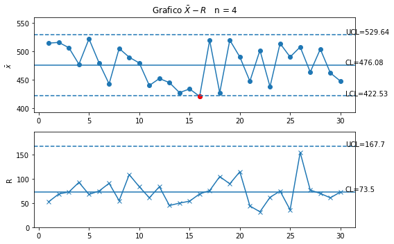

```python
n = 4 # Tamaño del grupo
A2, D3, D4, B3, B4 = calculate_control_limits_factors.f(n)

# Calcular el valor medio X y el rango R para cada grupo
df["xbar"] = df.iloc[:,:4].mean(axis=1)
df["R"] = df.iloc[:,0:4].max(axis=1) - df.iloc[:, 0:4].min(axis=1)
y = df['xbar']
y2 = df['R']

k = len(df) # Numero de grupos
l = k + 0.5
x = np.arange(1,k + 1)

# Calcular el valor medio total X y el valor medio del rango R
ym = df['xbar'].mean()
dm = df['R'].mean()

# Determinar las líneas de control (n=4)
ucl = ym + A2*dm
lcl = ym - A2*dm
UCL_R = D4*dm

out_of_control = [(i, value) for i, value in enumerate(y) if value > ucl or value < lcl]

# Crear el diagrama de control
fig, ax = plt.subplots(2,figsize=(8,5))

ax[0].plot(x,y,marker='o')

for i, value in out_of_control:
    ax[0].plot(x[i], y.iloc[i], marker='o', color='red')

ax[0].axhline(ucl, linestyle='--')
ax[0].axhline(ym, linestyle='-')
ax[0].axhline(lcl, linestyle='--')
ax[0].set_ylim(lcl-30,ucl+30)
ax[0].set_ylabel(r'$\bar{x}$')
ax[0].text(l,ucl,f"UCL={ucl:.2f}")
ax[0].text(l,ym,f"CL={ym:.2f}")
ax[0].text(l,lcl,f"LCL={lcl:.2f}")
ax[0].set_title(r'Grafico $\bar{X}-R $   ' + f'n = {n}')

ax[1].plot(x,y2, marker='x')
ax[1].axhline(dm, linestyle='-')
ax[1].axhline(UCL_R,linestyle='--')
ax[1].set_ylim(0,UCL_R+30)
ax[1].set_ylabel('R')
ax[1].text(l,UCL_R,f"UCL={UCL_R:.1f}")
ax[1].text(l,dm,f"CL={dm:.1f}")

a = "5_1"
plt.tight_layout()
plt.savefig("Graph3/Kanrizu_2_" + a + ".png", format="png", dpi=300, bbox_inches='tight',facecolor='white')

plt.show()
```

### 2. Cómo crear un gráfico de control $ p $ y un gráfico de control $ np $

管理図のつくり方

Entre los gráfico de control para **valores de conteo**, los más representativos son el **gráfico de control $ p $** y el **gráfico de control $ np $**. Cada uno de ellos es un gráfico de control de la **tasa de defectos** y del **número de defectos**, respectivamente. Cuando cada producto es clasificado individualmente como conforme o no conforme, se utiliza un gráfico **$ np $** se el **tamaño del grupo n es constante**, y un gráfico **$ p $** si el tamaño del grupo varía.

[Audio_4](https://drive.google.com/file/d/110vLxcCBh2KL5n20DNAA3ImXnYuMR5PG/view?usp=drive_link)

### (1) Cómo crear un gráfico de control $ p $

- Si el tamaño del grupo n **varía en cada grupo**, se representa en el gráfico de control la tasa de defectos de cada grupo.
- Se utiliza para controlar y variabilidad de la tasa de defectos entre los grupos.

Paso 1: Recopilar los datos.

- Recopilar entre 20 y 30 conjuntos de datos del tamaño del grupo (número de unidades inspeccionadas) $ n $ y el número de no conformidades np.

[Audio_5](https://drive.google.com/file/d/1TN9MQO_SyUOjTW620rVcAn8UIVvTIGD9/view?usp=drive_link)

```python
# スプレッドシートを開く（URLまたはスプレッドシートIDを使用）
SPREADSHEET_ID = "1kqN4PUhamo1jwqudnaHuaUSWvNX4tIbVTY5YU4g9r3A"
sheet = client.open_by_key(SPREADSHEET_ID).worksheet("Sheet17") # 最初のシートを取得

# データを取得
list_of_lists = sheet.get_all_records()
df = pd.DataFrame(list_of_lists)
df.reset_index(drop=True, inplace=True)

df = df.set_index('Número de grupo')
df = df.astype(float)

print('Tabla 5.2')
df
```

```
Tabla 5.2
```

| Número de grupo | Número de grupo n | Número de artículos defectuosos np | Tasa de artículos defectuosos p(%) |
| --- | --- | --- | --- |
| 1 | 100.0 | 5.0 | 5.00 |
| 2 | 120.0 | 8.0 | 6.67 |
| 3 | 140.0 | 9.0 | 6.43 |
| 4 | 180.0 | 2.0 | 1.11 |
| 5 | 200.0 | 1.0 | 0.50 |
| 6 | 85.0 | 1.0 | 1.18 |
| 7 | 69.0 | 0.0 | 0.00 |
| 8 | 100.0 | 8.0 | 8.00 |
| 9 | 112.0 | 9.0 | 8.04 |
| 10 | 160.0 | 4.0 | 2.50 |
| 11 | 123.0 | 6.0 | 4.88 |
| 12 | 147.0 | 3.0 | 2.04 |
| 13 | 89.0 | 2.0 | 2.25 |
| 14 | 67.0 | 1.0 | 1.49 |
| 15 | 60.0 | 1.0 | 1.67 |
| 16 | 80.0 | 3.0 | 3.75 |
| 17 | 70.0 | 5.0 | 7.14 |
| 18 | 90.0 | 6.0 | 6.67 |
| 19 | 56.0 | 4.0 | 7.14 |
| 20 | 125.0 | 5.0 | 4.00 |
| 21 | 140.0 | 5.0 | 3.57 |
| 22 | 140.0 | 3.0 | 2.14 |
| 23 | 160.0 | 2.0 | 1.25 |
| 24 | 130.0 | 6.0 | 4.62 |
| 25 | 150.0 | 8.0 | 5.33 |

Paso 2: Calcular la tasa de defectos $ p $ de cada grupo.

- $ p_i = (np)_i / n_i $

Paso 3: Calcular la tasa promedio de defectos $ \bar{p} $

Paso 4: Calcular las **líneas de control**

- Línea central $ CL = \bar{p} $
- Línea superior de control (UCL) $ UCL = \bar{p} + 3 \sqrt{\frac{1}{n_i} \bar{p} ( 1 - \bar{p}) } $
- Línea inferior de control (LCL) $ LCL = \bar{p} - 3 \sqrt{\frac{1}{n_i} \bar{p} ( 1 - \bar{p}) } $ $
- Los límites de control del diagrama de control p varían según el **tamaño del grupo**, por lo que es necesario calcularlos para **cada tamaño de grupo**.

Paso 5: Crear un gráfico de control

[Audio_6](https://drive.google.com/file/d/1G029FQcqcXvDNDZLkmM8ItKHqMs7L9KY/view?usp=drive_link)

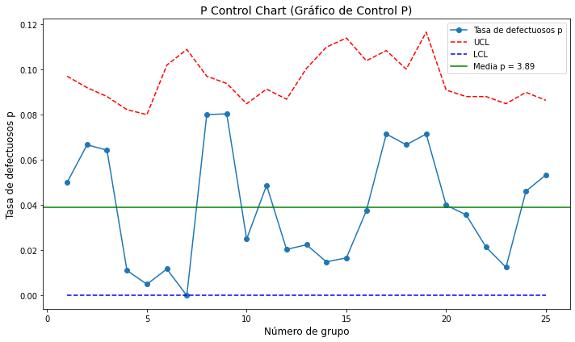

```python
# Calcular la proporción de np y n (tasa de defectos)
df['p'] = df['Número de artículos defectuosos np'] / df['Número de grupo n']

# Tasa promedio de defectos
p_barra = df['p'].mean()

# Calcular el UCL para cada grupo
df['UCL'] = p_barra + 3 * ((p_barra * (1 - p_barra)) / df['Número de grupo n']) ** 0.5

# Límite inferior de control )LCL=
df['LCL'] = p_barra - 3 * ((p_barra * (1 - p_barra)) / df['Número de grupo n']) ** 0.5
df['LCL'] = df['LCL'].apply(lambda x: max(x, 0))  #

# Clear el gráfico de control p
fig, ax = plt.subplots(figsize=(10, 6))

# Graficar el gráfico de control p
ax.plot(df.index, df['p'], marker='o', label='Tasa de defectuosos p')

# Graficar el UCL de cada grupo
ax.plot(df.index, df['UCL'], color='red', linestyle='--', label='UCL')

# Graficar el LCL de cada grupo
ax.plot(df.index, df['LCL'], color='blue', linestyle='--', label='LCL')

# Graficar la tasa promedio de defectos
ax.axhline(y=p_barra, color='green', linestyle='-', label=f'Media p = {p_barra*100:.2f}')

#
ax.set_title('P Control Chart (Gráfico de Control P)', fontsize=14)
ax.set_xlabel('Número de grupo', fontsize=12)
ax.set_ylabel('Tasa de defectuosos p', fontsize=12)

ax.legend()
plt.tight_layout()
plt.show()
```

### (1) Cómo crear un gráfico de control $ np $

Solo se puede utilizar cuando el tamaño de cada grupo $ n_i $ es **constante**. En este caso, se representa en el gráfico de control el número de defectos $ r_i = (np)_i $ de cada grupo.

Paso 1: Recolectar los datos.

- Recopilar entre 20 y 30 grupos de datos del tamaño del grupo (número de unidades inspeccionadas) $ n $ y el número de no conformidades $ np $

[Audio_7](https://drive.google.com/file/d/1GcmpZvSpW6VOpQ5e00X0LifUASAwilfC/view?usp=drive_link)

```python
# スプレッドシートを開く（URLまたはスプレッドシートIDを使用）
SPREADSHEET_ID = "1kqN4PUhamo1jwqudnaHuaUSWvNX4tIbVTY5YU4g9r3A"
sheet = client.open_by_key(SPREADSHEET_ID).worksheet("Sheet18") # 最初のシートを取得

# データを取得
list_of_lists = sheet.get_all_records()
df = pd.DataFrame(list_of_lists)
df.reset_index(drop=True, inplace=True)

df = df.set_index('Número de grupo')
df = df.astype(float)

df
```

| Número de grupo | Número de grupo n | Número de artículos defectuosos np |
| --- | --- | --- |
| 1 | 500.0 | 25.0 |
| 2 | 500.0 | 12.0 |
| 3 | 500.0 | 5.0 |
| 4 | 500.0 | 28.0 |
| 5 | 500.0 | 30.0 |
| 6 | 500.0 | 25.0 |
| 7 | 500.0 | 14.0 |
| 8 | 500.0 | 19.0 |
| 9 | 500.0 | 8.0 |
| 10 | 500.0 | 10.0 |
| 11 | 500.0 | 21.0 |
| 12 | 500.0 | 22.0 |
| 13 | 500.0 | 23.0 |
| 14 | 500.0 | 18.0 |
| 15 | 500.0 | 30.0 |
| 16 | 500.0 | 14.0 |
| 17 | 500.0 | 17.0 |
| 18 | 500.0 | 19.0 |
| 19 | 500.0 | 16.0 |
| 20 | 500.0 | 14.0 |
| 21 | 500.0 | 9.0 |
| 22 | 500.0 | 3.0 |
| 23 | 500.0 | 8.0 |
| 24 | 500.0 | 14.0 |
| 25 | 500.0 | 16.0 |

Paso 2: Calcular la tasa promedio de defectos $ \bar{p} $.

- $ \bar{p} = \frac{\sum (np)_i }{\sum n_i} $

Paso 3: Calcular las líneas de control

- $ CL = n\bar{p} $
- $ UCL = np + 3 \sqrt{n\bar{p}(1-p)} $
- $ LCL = np - 3 \sqrt{n\bar{p}(1-p)} $

Paso 4: Crear un gráfico de control np

[Audio_8](https://drive.google.com/file/d/1r7gFGPQUvqTLLxJBt-k5BVxK88ZPW2VP/view?usp=drive_link)

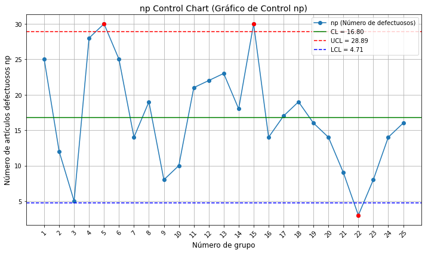

```python
# Calcular el valor promedio de np
np_barra = df['Número de artículos defectuosos np'].mean()
p_barra = df['Número de artículos defectuosos np'].sum()/df['Número de grupo n'].sum()

# Calcular los límites de control（UCL, LCL）
UCL = np_barra + 3 * (np_barra * (1 - p_barra)) ** 0.5
LCL = np_barra - 3 * (np_barra * (1 - p_barra)) ** 0.5
LCL = max(LCL, 0)  #

y = df['Número de artículos defectuosos np']
out_of_control = [(i, value) for i, value in enumerate(y) if value > UCL or value < LCL]

# Crear el gráfico de control np
fig, ax = plt.subplots(figsize=(10, 6))
ax.plot(df.index, y, marker='o', label='np (Número de defectuosos)')

for i, value in out_of_control:
    ax.plot(df.index[i], y.iloc[i], marker='o', color='red')

ax.axhline(y=np_barra, color='green', linestyle='-', label=f'CL = {np_barra:.2f}')
ax.axhline(y=UCL, color='red', linestyle='--', label=f'UCL = {UCL:.2f}')
ax.axhline(y=LCL, color='blue', linestyle='--', label=f'LCL = {LCL:.2f}')

xticks = df.index[::1]
ax.set_xticks(xticks)
ax.set_xticklabels(xticks, rotation=45)

ax.set_title('np Control Chart (Gráfico de Control np)', fontsize=14)
ax.set_xlabel('Número de grupo', fontsize=12)
ax.set_ylabel('Número de artículos defectuosos np', fontsize=12)
ax.legend()

plt.grid(True)
plt.tight_layout()
plt.show()
```

## 05-03 Cómo interpretar y utilizar el gráfico de control

管理図の見方・使い方

### 1. Cómo interpretar el gráfico de control

管理図の見方

En la gestión de procesos, es crucial juzgar correctamente si el proceso se encuentra en una **estado de control estadístico** mediante el uso de gráficos de control.

Si se detecta alguna anomalía, es necesario investigar la causa de inmediato y tomar las medidas correctivas.

#### (1) Determinación del estado de control estadístico.

統計的管理状態の判定

El **estado de control estadístico** se refiere a una condición en la que el promedio del proceso y la variabilidad no cambian.

1. Los puntos del gráfico de control están **dentro de los límites de control**
2. **No hay patrones inusuales** en la distribución o disposición de los puntos.

Si se cumplen estas condiciones, el proceso se considera en estado de control.

[Audio_9](https://drive.google.com/file/d/1wlnRzeEV8WzytHEuA_yOSWWGAPUvt6R4/view?usp=drive_link)

### (2) Reglas para la determinación de anomalías en el proceso

工程異常の判定のためのルール

1. Un punto del gráfico de control está **fuera de los límites** de control (Regla 1) 管理図の点が管理限界の外側にある

[Audio_10](https://drive.google.com/file/d/1adPTK7qvou4WSSzNgDm1bkq9SErCyPBZ/view?usp=drive_link)

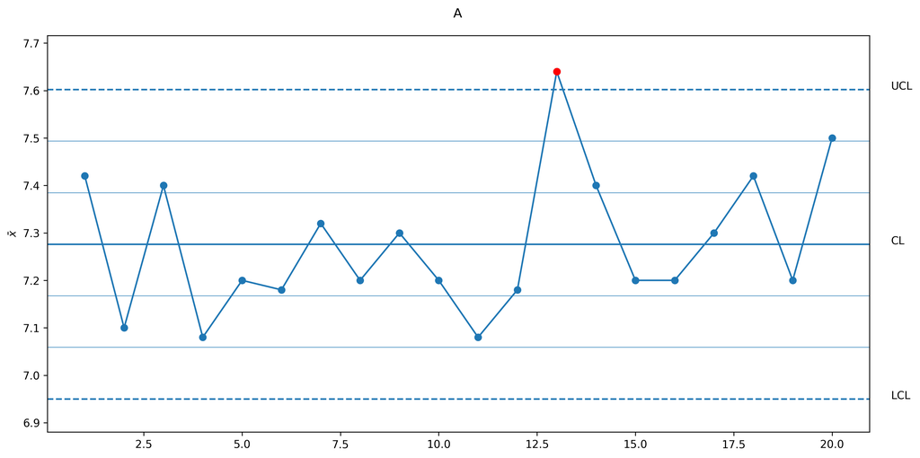

```python
from PIL import Image

img = Image.open("Graph3/Kanrizu_2_A.png")
display(img)
```

1. Cuando los puntos **aparecen consecutivamente en el mismo lado** de la líneas central (Regra 2) 点が中心点に対して同じ側に連続して現れる

[Audio_11](https://drive.google.com/file/d/1kEy-nmgQEZjqSVLZje8ebnk7FEjluH1k/view?usp=drive_link)

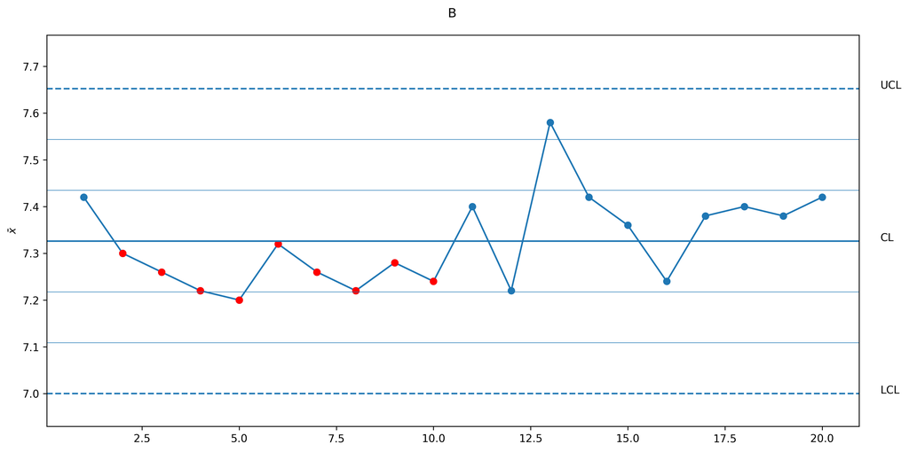

```python
img = Image.open('Graph3/Kanrizu_2_B.png')
display(img)
```

1. Puntos que **continúan aumentando o disminuyendo** (Regla 3) 点が引き続き増加または減少している

[Audio_12](https://drive.google.com/file/d/1nzDYXyJC9KrG61mcKUA7Eb4mtlOTY5sq/view?usp=drive_link)

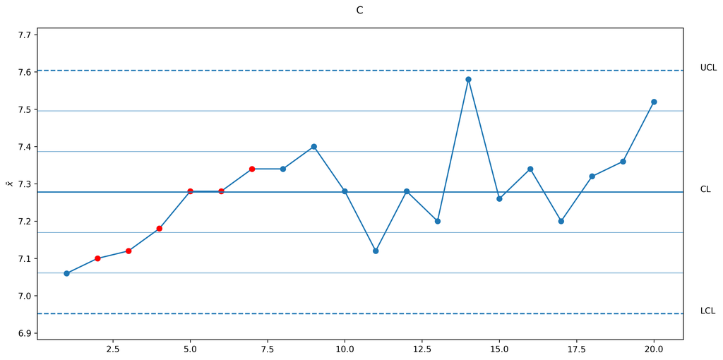

```python
img = Image.open('Graph3/Kanrizu_2_C.png')
display(img)
```

1. Puntos con un patrón claramente **no aleatorio** o **un patrón periódico** (Regla 4) 点が明らかに不規則でないパターンまたは周期的なパターン

[Audio_13](https://drive.google.com/file/d/1zUA4BR6WVRkBozUDldl8oFc3NXVEf1pY/view?usp=drive_link)

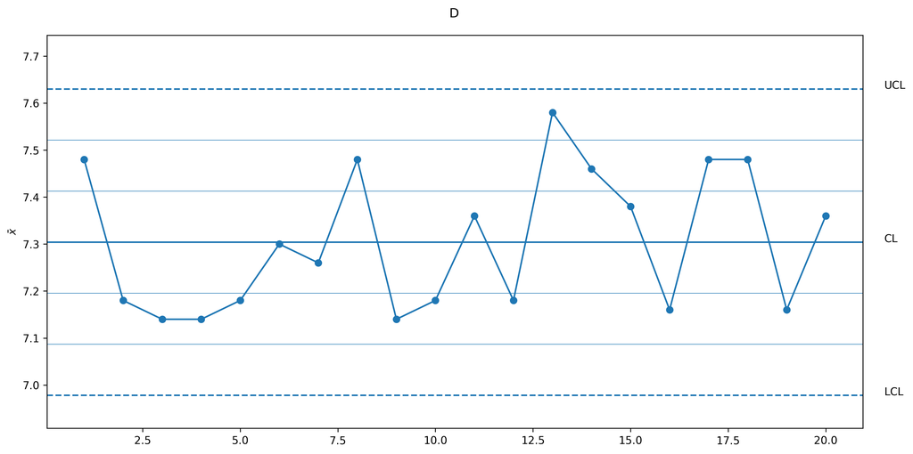

```python
img = Image.open('Graph3/Kanrizu_2_D.png')
display(img)
```

### 5.2

例題５．１で作成した $ \bar{X} - R $管理図について、統計的な管理状態であるかどうかを判断せよ。

Determina si el gráfico de control $ \bar{X} - R $ creado en el Ejemplo 5.1 está en estado de control estadístico.

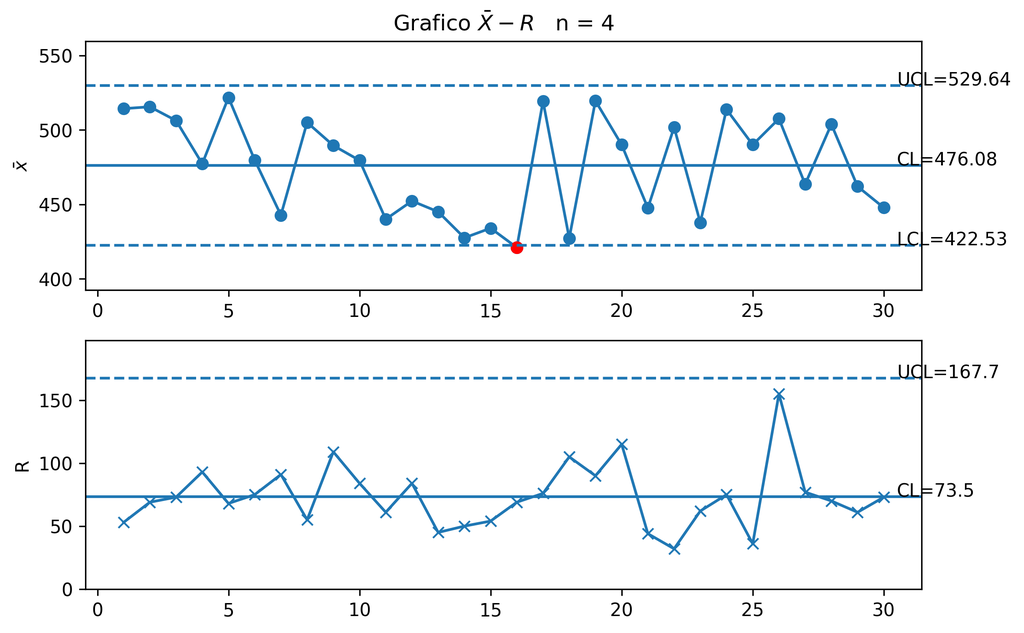

```python
img = Image.open('Graph3/Kanrizu_2_5_1.png')
display(img)
```

En el gráfico de control R, los puntos **no presentan anomalías**. Sin embargo, en el gráfico de control $ \bar{X} $, se observa un punto **fuera de los límites** de control en el grupo número 16, se detecta una **variación periódica** entre los grupos números 20 y 29. Por lo tanto, se concluye que no está en estado de control estadístico.

[Audio_14](https://drive.google.com/file/d/1fmhq_-oE4wLnw5D-ppgf2QJL4034OKAg/view?usp=drive_link)

### 2. Uso del gráfico de control

管理図の使い方

#### (I) Estrategías para la agrupación

群分けの工夫

La calidad de la agrupación es un punto clave para obtener un gráfico de control útil. El objetivo de un gráfico de control es juzgar la variabilidad debida a causas especiales basándose en la variabilidad debida a causas comunes. Por lo tanto, para que la variabilidad dentro del grupo está compuesta por variabilidad debida a causas comunes, los datos del mismo días se agrupan, o los datos de lotes donde el trabajo se realiza bajo las mismas condiciones se agrupan.

- Variabilidad debida a causa aleatorias
- Variabilidad debida a causa asignables.

#### (2) Estratificación

層別

En los gráficos de control, el concepto de **estratificación** también es importante. Cuando varios operarios o diferentes máquinas fabrican el mismo producto, la estratificación por máquina o por operario puede facilitar el análisis y la gestión del proceso.

[Audio_15](https://drive.google.com/file/d/1KyCcpZMBRL__Za6WT3fagRPsIOoyIQmm/view?usp=drive_link)

```python
import itertools
from IPython.display import Image, display
def detect_out_of_control(y, cl, threshold=7):
    out_of_control = []

    # 連続した高値・低値のグループを見つける
    # 高い状態が続くか低い状態が続くかを個別に検出
    for key, group in itertools.groupby(enumerate(y), lambda x: x[1] >= cl):
        group_list = list(group)
        if key and len(group_list) >= threshold:
            out_of_control.extend(group_list)

    for key, group in itertools.groupby(enumerate(y), lambda x: x[1] <= cl):
        group_list = list(group)
        if key and len(group_list) >= threshold:
            out_of_control.extend(group_list)

    return out_of_control


def detect_trend_out_of_control(y, threshold=7):
    out_of_control = []
    increasing_streak = []
    decreasing_streak = []

    for i in range(1, len(y)):
        if y[i] > y[i - 1]:  # 増加
            increasing_streak.append((i, y[i]))
            decreasing_streak.clear()
        elif y[i] < y[i - 1]:  # 減少
            decreasing_streak.append((i, y[i]))
            increasing_streak.clear()
        else:
            increasing_streak.clear()
            decreasing_streak.clear()

        if len(increasing_streak) >= threshold-1:
            out_of_control.extend(increasing_streak)
        if len(decreasing_streak) >= threshold:
            out_of_control.extend(decreasing_streak)

    return out_of_control

def f (fa, a):
  fa = fa
  A = []

  for d in fa:
    # 目標のデータ範囲
    target_range = d[1]
    mean = d[0]

    k = len(fa) # Numero de grupos
    l = k + 0.5

    while True:
        # 平均と標準偏差を指定
        std_dev = target_range / 4  # データ範囲の最大値を4倍する

        # サンプルデータを生成
        sample_data = np.random.normal(mean, std_dev, 5)
        sample_data = np.round(sample_data,1)

        # データの範囲を計算
        data_range = np.max(sample_data) - np.min(sample_data)
        data_mean = np.mean(sample_data)
        data_sigma = np.std(sample_data, ddof=1)

        # データ範囲が目標に近い場合はループを抜ける
        if abs(data_range - target_range) < 0.01:
          if abs(data_mean - mean) < 0.02:  # 許容誤差
            break
    A += [sample_data]

  df = pd.DataFrame(A)
  df3 = df.copy()

  df['xbar'] = df3.mean(axis=1)
  df['R'] = df3.max(axis=1) - df3.min(axis=1)
  df['s'] = df3.std(axis=1, ddof=1)
  df.to_excel('Data3/Kanrizu_' + a + '.xlsx')
  df3.to_csv('Data3/Kanrizu_' + a + '.csv', index=True)

  #グラフを表示する領域を，figオブジェクトとして作成。
  fig, ax = plt.subplots(1,figsize=(12,6))
  fig.suptitle(a)

  x = np.arange(1,k+1)
  y = df['xbar']
  y2 = df['R']
  ym = df['xbar'].mean()
  dm = df['R'].mean()
  dsigma = 0.577*dm/3

  ucl  = ym + 3*dsigma
  ucl1 = ym + 2*dsigma
  ucl2 = ym + dsigma

  lcl = ym  - 3*dsigma
  lcl1 = ym - 2*dsigma
  lcl2 = ym - dsigma

  out_of_control = [(i, value) for i, value in enumerate(y) if value > ucl or value < lcl]

  out_of_control2 = detect_out_of_control(y, ym)

  out_of_control3 = detect_trend_out_of_control(y)

  ax.plot(x,y,marker='o')
  for i, value in out_of_control:
    ax.plot(x[i], y.iloc[i], marker='o', color='red')

  for i, value in out_of_control2:
    ax.plot(x[i], y.iloc[i], marker='o', color='red')

  for i, value in out_of_control3:
    ax.plot(x[i], y.iloc[i], marker='o', color='red')

  ax.axhline(ucl, linestyle='--')
  ax.axhline(ucl1, linestyle='-', linewidth=0.5)
  ax.axhline(ucl2, linestyle='-', linewidth=0.5)
  ax.axhline(ym, linestyle='-')
  ax.axhline(lcl, linestyle='--')
  ax.axhline(lcl1, linestyle='-', linewidth=0.5)
  ax.axhline(lcl2, linestyle='-', linewidth=0.5)

  ax.set_ylim(lcl*0.99,ucl*1.015)
  ax.set_ylabel(r'$\bar{x}$')
  ax.text(k+1.5,ucl,"UCL")
  ax.text(k+1.5,ym,"CL")
  ax.text(k+1.5,lcl,"LCL")

  plt.tight_layout()
  plt.savefig("Graph3/Kanrizu_2_" + a + ".png", format="png", dpi=300, bbox_inches='tight', facecolor='white')

  print(y.mean(), ucl, lcl)

  chart = QCChart(df3, 5)
  img_data = chart.to_base64()
  display(Image(data=base64.b64decode(img_data)))
```

```
7.276999999999999 7.603005 6.950994999999999
```

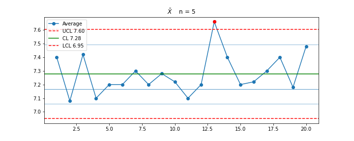

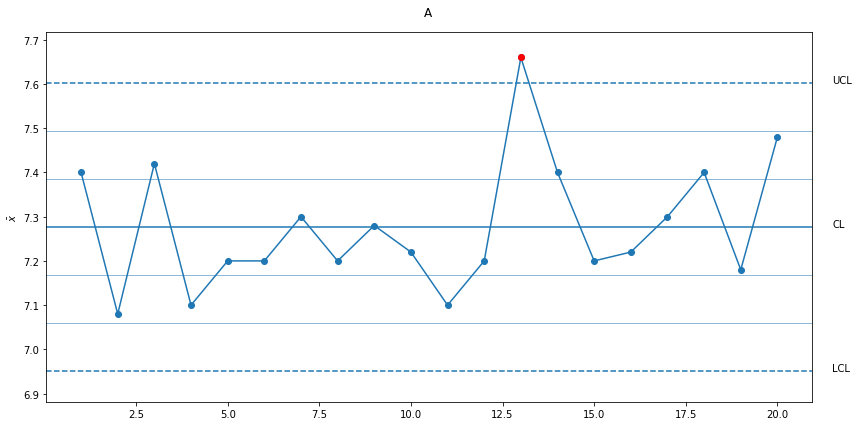

```python
# スプレッドシートを開く（URLまたはスプレッドシートIDを使用）
SPREADSHEET_ID = "1Y7lmoNn7CoScUpjWNmBAnL90YTLzdtOUef8EMoeIbTY"
sheet = client.open_by_key(SPREADSHEET_ID).worksheet("Sheet13") # 最初のシートを取得

# データを取得
list_of_lists = sheet.get_all_values()
df = pd.DataFrame(list_of_lists)

df.columns = df.iloc[0]
df = df.drop(df.index[0])

# インデックスをリセット
df.reset_index(drop=True, inplace=True)

data = df.iloc[:,1:3].values

floatArray = np.asarray(data, dtype=float)

f(floatArray,'A')
```

```
7.325 7.6510050000000005 6.998995
```

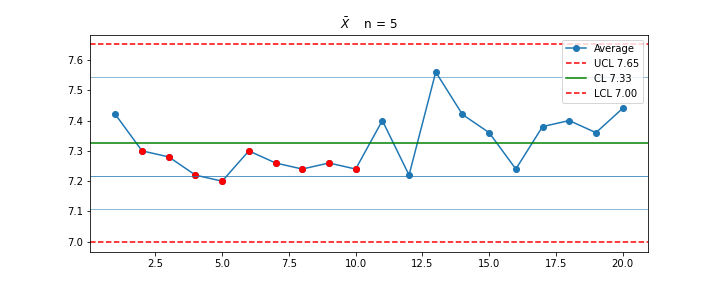

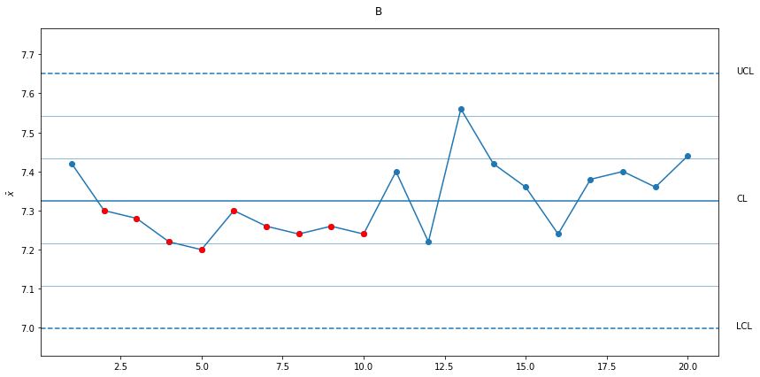

```python
sheet = client.open_by_key(SPREADSHEET_ID).worksheet("Sheet14") # 最初のシートを取得

# データを取得
list_of_lists = sheet.get_all_values()
df = pd.DataFrame(list_of_lists)

df.columns = df.iloc[0]
df = df.drop(df.index[0])

# インデックスをリセット
df.reset_index(drop=True, inplace=True)

data = df.iloc[:,1:3].values

floatArray = np.asarray(data, dtype=float)

f(floatArray,'B')
```

```
7.276999999999999 7.603005 6.950994999999999
```

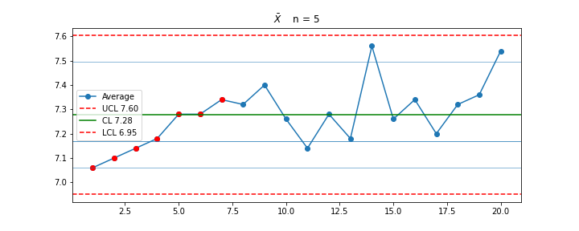

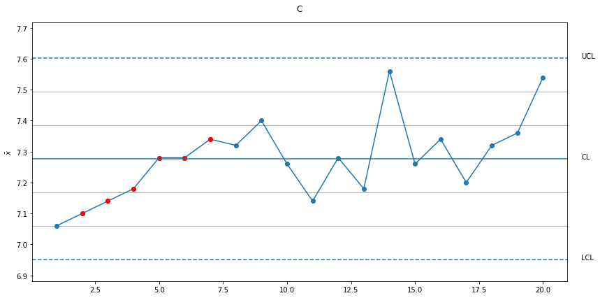

```python
sheet = client.open_by_key(SPREADSHEET_ID).worksheet("Sheet15") # 最初のシートを取得

# データを取得
list_of_lists = sheet.get_all_values()
df = pd.DataFrame(list_of_lists)

df.columns = df.iloc[0]
df = df.drop(df.index[0])

# インデックスをリセット
df.reset_index(drop=True, inplace=True)

data = df.iloc[:,1:3].values

floatArray = np.asarray(data, dtype=float)

f(floatArray,'C')
```

```
7.302 7.628005 6.975994999999999
```

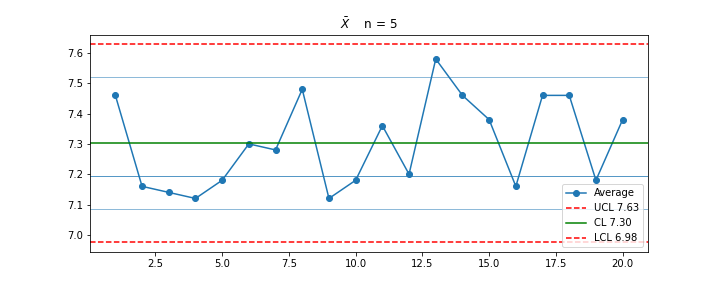

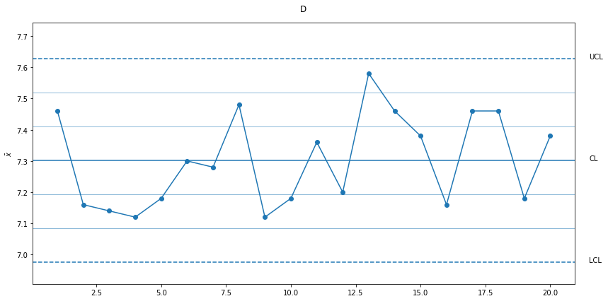

```python
sheet = client.open_by_key(SPREADSHEET_ID).worksheet("Sheet16") # 最初のシートを取得

# データを取得
list_of_lists = sheet.get_all_values()
df = pd.DataFrame(list_of_lists)

df.columns = df.iloc[0]
df = df.drop(df.index[0])

# インデックスをリセット
df.reset_index(drop=True, inplace=True)

data = df.iloc[:,1:3].values

floatArray = np.asarray(data, dtype=float)

f(floatArray,'D')
```

## Por favor, responda a las preguntas del examen de práctica a través del siguiente enlace.

[Simulacro de examen](https://forms.gle/YdvvfPwNw16UNNiT8)

```python
notebook_name = 'QCKentei3-5.ipynb'
notebook_name_html = notebook_name.replace(".ipynb",".html")

!jupyter nbconvert --to html {notebook_name}
```

```
[NbConvertApp] Converting notebook QCKentei3-5.ipynb to html
[NbConvertApp] Writing 3643479 bytes to QCKentei3-5.html
```